# 628 module 2

STAT 628

Group 1

Oct. 18, 2021

```r
library(car)
library(ggm)
library(corpcor)
library(nlme)
library(ggplot2)
```

## Data cleaning

```r
data <- read.csv("BodyFat.csv")
summary(data)
```

```
##       IDNO           BODYFAT         DENSITY           AGE
##  Min.   :  1.00   Min.   : 0.00   Min.   :0.995   Min.   :22.00
##  1st Qu.: 63.75   1st Qu.:12.80   1st Qu.:1.041   1st Qu.:35.75
##  Median :126.50   Median :19.00   Median :1.055   Median :43.00
##  Mean   :126.50   Mean   :18.94   Mean   :1.056   Mean   :44.88
##  3rd Qu.:189.25   3rd Qu.:24.60   3rd Qu.:1.070   3rd Qu.:54.00
##  Max.   :252.00   Max.   :45.10   Max.   :1.109   Max.   :81.00
##      WEIGHT          HEIGHT        ADIPOSITY          NECK
##  Min.   :118.5   Min.   :29.50   Min.   :18.10   Min.   :31.10
##  1st Qu.:159.0   1st Qu.:68.25   1st Qu.:23.10   1st Qu.:36.40
##  Median :176.5   Median :70.00   Median :25.05   Median :38.00
##  Mean   :178.9   Mean   :70.15   Mean   :25.44   Mean   :37.99
##  3rd Qu.:197.0   3rd Qu.:72.25   3rd Qu.:27.32   3rd Qu.:39.42
##  Max.   :363.1   Max.   :77.75   Max.   :48.90   Max.   :51.20
##      CHEST           ABDOMEN            HIP            THIGH
##  Min.   : 79.30   Min.   : 69.40   Min.   : 85.0   Min.   :47.20
##  1st Qu.: 94.35   1st Qu.: 84.58   1st Qu.: 95.5   1st Qu.:56.00
##  Median : 99.65   Median : 90.95   Median : 99.3   Median :59.00
##  Mean   :100.82   Mean   : 92.56   Mean   : 99.9   Mean   :59.41
##  3rd Qu.:105.38   3rd Qu.: 99.33   3rd Qu.:103.5   3rd Qu.:62.35
##  Max.   :136.20   Max.   :148.10   Max.   :147.7   Max.   :87.30
##       KNEE           ANKLE          BICEPS         FOREARM          WRIST
##  Min.   :33.00   Min.   :19.1   Min.   :24.80   Min.   :21.00   Min.   :15.80
##  1st Qu.:36.98   1st Qu.:22.0   1st Qu.:30.20   1st Qu.:27.30   1st Qu.:17.60
##  Median :38.50   Median :22.8   Median :32.05   Median :28.70   Median :18.30
##  Mean   :38.59   Mean   :23.1   Mean   :32.27   Mean   :28.66   Mean   :18.23
##  3rd Qu.:39.92   3rd Qu.:24.0   3rd Qu.:34.33   3rd Qu.:30.00   3rd Qu.:18.80
##  Max.   :49.10   Max.   :33.9   Max.   :45.00   Max.   :34.90   Max.   :21.40
```

Two observations have implausible body fat values: 172 and 182

```r
data[data[,"BODYFAT"] < 3,]
```

|  | IDNO | BODYFAT | DENSITY | AGE | WEIGHT | HEIGHT | ADIPOSITY | NECK | CHEST | ABDOMEN | HIP | THIGH | KNEE | ANKLE | BICEPS | FOREARM | WRIST |
| --- | --- | --- | --- | --- | --- | --- | --- | --- | --- | --- | --- | --- | --- | --- | --- | --- | --- |
| 172 | 172 | 1.9 | 1.0983 | 35 | 125.75 | 65.5 | 20.6 | 34.0 | 90.8 | 75.0 | 89.2 | 50.0 | 34.8 | 22.0 | 24.8 | 25.9 | 16.9 |
| 182 | 182 | 0.0 | 1.1089 | 40 | 118.50 | 68.0 | 18.1 | 33.8 | 79.3 | 69.4 | 85.0 | 47.2 | 33.5 | 20.2 | 27.7 | 24.6 | 16.5 |

Five observations have incorrect density or body fat measurements based on Siri’s equation: 48, 76, 96, 182, 216

```r
data$SIRIS_ERROR = (495/data$DENSITY)-450 - data$BODYFAT
data[abs(data[,"SIRIS_ERROR"]) > 2,]
```

|  | IDNO | BODYFAT | DENSITY | AGE | WEIGHT | HEIGHT | ADIPOSITY | NECK | CHEST | ABDOMEN | HIP | THIGH | KNEE | ANKLE | BICEPS | FOREARM | WRIST | SIRIS_ERROR |
| --- | --- | --- | --- | --- | --- | --- | --- | --- | --- | --- | --- | --- | --- | --- | --- | --- | --- | --- |
| 48 | 48 | 6.4 | 1.0665 | 39 | 148.50 | 71.25 | 20.6 | 34.6 | 89.8 | 79.5 | 92.7 | 52.7 | 37.5 | 21.9 | 28.8 | 26.8 | 17.9 | 7.735021 |
| 76 | 76 | 18.3 | 1.0666 | 61 | 148.25 | 67.50 | 22.9 | 36.0 | 91.6 | 81.8 | 94.8 | 54.5 | 37.0 | 21.4 | 29.3 | 27.0 | 18.3 | -4.208494 |
| 96 | 96 | 17.3 | 1.0991 | 53 | 224.50 | 77.75 | 26.1 | 41.1 | 113.2 | 99.2 | 107.5 | 61.7 | 42.3 | 23.2 | 32.9 | 30.8 | 20.4 | -16.931517 |
| 182 | 182 | 0.0 | 1.1089 | 40 | 118.50 | 68.00 | 18.1 | 33.8 | 79.3 | 69.4 | 85.0 | 47.2 | 33.5 | 20.2 | 27.7 | 24.6 | 16.5 | -3.611687 |
| 216 | 216 | 45.1 | 0.9950 | 51 | 219.00 | 64.00 | 37.6 | 41.2 | 119.8 | 122.1 | 112.8 | 62.5 | 36.9 | 23.6 | 34.7 | 29.1 | 18.4 | 2.387437 |

BMI is weight/height^2 * 703

Three rows have incorrect BMI, weight, or height: 42, 163, 221

```r
data$BMI_ERROR = data$WEIGHT/((data$HEIGHT)^2)*703 - data$ADIPOSITY
data[abs(data[,"BMI_ERROR"]) > 2,]
```

|  | IDNO | BODYFAT | DENSITY | AGE | WEIGHT | HEIGHT | ADIPOSITY | NECK | CHEST | ABDOMEN | HIP | THIGH | KNEE | ANKLE | BICEPS | FOREARM | WRIST | SIRIS_ERROR | BMI_ERROR |
| --- | --- | --- | --- | --- | --- | --- | --- | --- | --- | --- | --- | --- | --- | --- | --- | --- | --- | --- | --- |
| 42 | 42 | 31.7 | 1.0250 | 44 | 205.00 | 29.50 | 29.9 | 36.6 | 106.0 | 104.3 | 115.5 | 70.6 | 42.5 | 23.7 | 33.6 | 28.7 | 17.4 | 1.2268293 | 135.701839 |
| 163 | 163 | 13.3 | 1.0690 | 33 | 184.25 | 68.75 | 24.4 | 40.7 | 98.9 | 92.1 | 103.5 | 64.0 | 37.3 | 23.5 | 33.5 | 30.6 | 19.7 | -0.2504210 | 3.004218 |
| 221 | 221 | 12.7 | 1.0706 | 54 | 153.25 | 70.50 | 24.5 | 38.5 | 99.0 | 91.8 | 96.2 | 57.7 | 38.1 | 23.9 | 31.4 | 29.9 | 18.9 | -0.3424435 | -2.824078 |

Nine rows need to be replaced or imputated: 42, 48, 76, 96, 163, 172, 182, 216, 221 Since this is only 3.6% of the data and it seems to be inaccurate at random, we’ll simply remove these rows.

```r
newdata = data[-c(42, 48, 76, 96, 163, 172, 182, 216, 221), ]
newdata = subset(newdata, select = -c(SIRIS_ERROR,BMI_ERROR))
newdata
```

|  | IDNO | BODYFAT | DENSITY | AGE | WEIGHT | HEIGHT | ADIPOSITY | NECK | CHEST | ABDOMEN | HIP | THIGH | KNEE | ANKLE | BICEPS | FOREARM | WRIST |
| --- | --- | --- | --- | --- | --- | --- | --- | --- | --- | --- | --- | --- | --- | --- | --- | --- | --- |
| 1 | 1 | 12.6 | 1.0708 | 23 | 154.25 | 67.75 | 23.7 | 36.2 | 93.1 | 85.2 | 94.5 | 59.0 | 37.3 | 21.9 | 32.0 | 27.4 | 17.1 |
| 2 | 2 | 6.9 | 1.0853 | 22 | 173.25 | 72.25 | 23.4 | 38.5 | 93.6 | 83.0 | 98.7 | 58.7 | 37.3 | 23.4 | 30.5 | 28.9 | 18.2 |
| 3 | 3 | 24.6 | 1.0414 | 22 | 154.00 | 66.25 | 24.7 | 34.0 | 95.8 | 87.9 | 99.2 | 59.6 | 38.9 | 24.0 | 28.8 | 25.2 | 16.6 |
| 4 | 4 | 10.9 | 1.0751 | 26 | 184.75 | 72.25 | 24.9 | 37.4 | 101.8 | 86.4 | 101.2 | 60.1 | 37.3 | 22.8 | 32.4 | 29.4 | 18.2 |
| 5 | 5 | 27.8 | 1.0340 | 24 | 184.25 | 71.25 | 25.6 | 34.4 | 97.3 | 100.0 | 101.9 | 63.2 | 42.2 | 24.0 | 32.2 | 27.7 | 17.7 |
| 6 | 6 | 20.6 | 1.0502 | 24 | 210.25 | 74.75 | 26.5 | 39.0 | 104.5 | 94.4 | 107.8 | 66.0 | 42.0 | 25.6 | 35.7 | 30.6 | 18.8 |
| 7 | 7 | 19.0 | 1.0549 | 26 | 181.00 | 69.75 | 26.2 | 36.4 | 105.1 | 90.7 | 100.3 | 58.4 | 38.3 | 22.9 | 31.9 | 27.8 | 17.7 |
| 8 | 8 | 12.8 | 1.0704 | 25 | 176.00 | 72.50 | 23.6 | 37.8 | 99.6 | 88.5 | 97.1 | 60.0 | 39.4 | 23.2 | 30.5 | 29.0 | 18.8 |
| 9 | 9 | 5.1 | 1.0900 | 25 | 191.00 | 74.00 | 24.6 | 38.1 | 100.9 | 82.5 | 99.9 | 62.9 | 38.3 | 23.8 | 35.9 | 31.1 | 18.2 |
| 10 | 10 | 12.0 | 1.0722 | 23 | 198.25 | 73.50 | 25.8 | 42.1 | 99.6 | 88.6 | 104.1 | 63.1 | 41.7 | 25.0 | 35.6 | 30.0 | 19.2 |

[output cut: 233 more lines]

Writing the cleaned up data to a csv:

```r
write.csv(newdata, "bodyfat_cleaned.csv")
```

## Deal with data

```r
# read the data
BodyFat_clean <- read.csv('bodyfat_cleaned.csv',sep = ',')
BodyFat_clean <- BodyFat_clean[,c(3,5:18)]
```

```r
# look the data
head(BodyFat_clean)
```

|  | BODYFAT | AGE | WEIGHT | HEIGHT | ADIPOSITY | NECK | CHEST | ABDOMEN | HIP | THIGH | KNEE | ANKLE | BICEPS | FOREARM | WRIST |
| --- | --- | --- | --- | --- | --- | --- | --- | --- | --- | --- | --- | --- | --- | --- | --- |
| 1 | 12.6 | 23 | 154.25 | 67.75 | 23.7 | 36.2 | 93.1 | 85.2 | 94.5 | 59.0 | 37.3 | 21.9 | 32.0 | 27.4 | 17.1 |
| 2 | 6.9 | 22 | 173.25 | 72.25 | 23.4 | 38.5 | 93.6 | 83.0 | 98.7 | 58.7 | 37.3 | 23.4 | 30.5 | 28.9 | 18.2 |
| 3 | 24.6 | 22 | 154.00 | 66.25 | 24.7 | 34.0 | 95.8 | 87.9 | 99.2 | 59.6 | 38.9 | 24.0 | 28.8 | 25.2 | 16.6 |
| 4 | 10.9 | 26 | 184.75 | 72.25 | 24.9 | 37.4 | 101.8 | 86.4 | 101.2 | 60.1 | 37.3 | 22.8 | 32.4 | 29.4 | 18.2 |
| 5 | 27.8 | 24 | 184.25 | 71.25 | 25.6 | 34.4 | 97.3 | 100.0 | 101.9 | 63.2 | 42.2 | 24.0 | 32.2 | 27.7 | 17.7 |
| 6 | 20.6 | 24 | 210.25 | 74.75 | 26.5 | 39.0 | 104.5 | 94.4 | 107.8 | 66.0 | 42.0 | 25.6 | 35.7 | 30.6 | 18.8 |

```r
tail(BodyFat_clean)
```

|  | BODYFAT | AGE | WEIGHT | HEIGHT | ADIPOSITY | NECK | CHEST | ABDOMEN | HIP | THIGH | KNEE | ANKLE | BICEPS | FOREARM | WRIST |
| --- | --- | --- | --- | --- | --- | --- | --- | --- | --- | --- | --- | --- | --- | --- | --- |
| 238 | 29.1 | 69 | 215.50 | 70.50 | 30.5 | 40.8 | 113.7 | 107.6 | 110.0 | 63.3 | 44.0 | 22.6 | 37.5 | 32.6 | 18.8 |
| 239 | 11.5 | 70 | 134.25 | 67.00 | 21.1 | 34.9 | 89.2 | 83.6 | 88.8 | 49.6 | 34.8 | 21.5 | 25.6 | 25.7 | 18.5 |
| 240 | 32.3 | 72 | 201.00 | 69.75 | 29.1 | 40.9 | 108.5 | 105.0 | 104.5 | 59.6 | 40.8 | 23.2 | 35.2 | 28.6 | 20.1 |
| 241 | 28.3 | 72 | 186.75 | 66.00 | 30.2 | 38.9 | 111.1 | 111.5 | 101.7 | 60.3 | 37.3 | 21.5 | 31.3 | 27.2 | 18.0 |
| 242 | 25.3 | 72 | 190.75 | 70.50 | 27.0 | 38.9 | 108.3 | 101.3 | 97.8 | 56.0 | 41.6 | 22.7 | 30.5 | 29.4 | 19.8 |
| 243 | 30.7 | 74 | 207.50 | 70.00 | 29.8 | 40.8 | 112.4 | 108.5 | 107.1 | 59.3 | 42.2 | 24.6 | 33.7 | 30.0 | 20.9 |

```r
summary(BodyFat_clean)
```

```
##     BODYFAT           AGE            WEIGHT          HEIGHT
##  Min.   : 4.10   Min.   :22.00   Min.   :125.0   Min.   :64.00
##  1st Qu.:13.30   1st Qu.:35.50   1st Qu.:159.8   1st Qu.:68.50
##  Median :19.10   Median :43.00   Median :176.8   Median :70.25
##  Mean   :19.04   Mean   :44.86   Mean   :179.3   Mean   :70.35
##  3rd Qu.:24.60   3rd Qu.:54.00   3rd Qu.:196.9   3rd Qu.:72.25
##  Max.   :38.20   Max.   :81.00   Max.   :363.1   Max.   :77.50
##    ADIPOSITY          NECK           CHEST           ABDOMEN
##  Min.   :19.10   Min.   :31.10   Min.   : 83.40   Min.   : 70.40
##  1st Qu.:23.15   1st Qu.:36.40   1st Qu.: 94.75   1st Qu.: 85.25
##  Median :25.10   Median :38.00   Median : 99.70   Median : 90.90
##  Mean   :25.45   Mean   :38.01   Mean   :100.90   Mean   : 92.63
##  3rd Qu.:27.35   3rd Qu.:39.40   3rd Qu.:105.30   3rd Qu.: 99.45
##  Max.   :48.90   Max.   :51.20   Max.   :136.20   Max.   :148.10
##       HIP             THIGH            KNEE           ANKLE
##  Min.   : 85.30   Min.   :49.30   Min.   :33.00   Min.   :19.10
##  1st Qu.: 95.60   1st Qu.:56.10   1st Qu.:37.10   1st Qu.:22.00
##  Median : 99.30   Median :59.00   Median :38.60   Median :22.80
##  Mean   : 99.91   Mean   :59.46   Mean   :38.62   Mean   :23.12
##  3rd Qu.:103.15   3rd Qu.:62.30   3rd Qu.:39.95   3rd Qu.:24.00
##  Max.   :147.70   Max.   :87.30   Max.   :49.10   Max.   :33.90
##      BICEPS         FOREARM          WRIST
##  Min.   :25.30   Min.   :21.00   Min.   :15.80
##  1st Qu.:30.30   1st Qu.:27.30   1st Qu.:17.60
##  Median :32.10   Median :28.70   Median :18.30
##  Mean   :32.33   Mean   :28.68   Mean   :18.23
##  3rd Qu.:34.40   3rd Qu.:30.00   3rd Qu.:18.80
##  Max.   :45.00   Max.   :34.90   Max.   :21.40
```

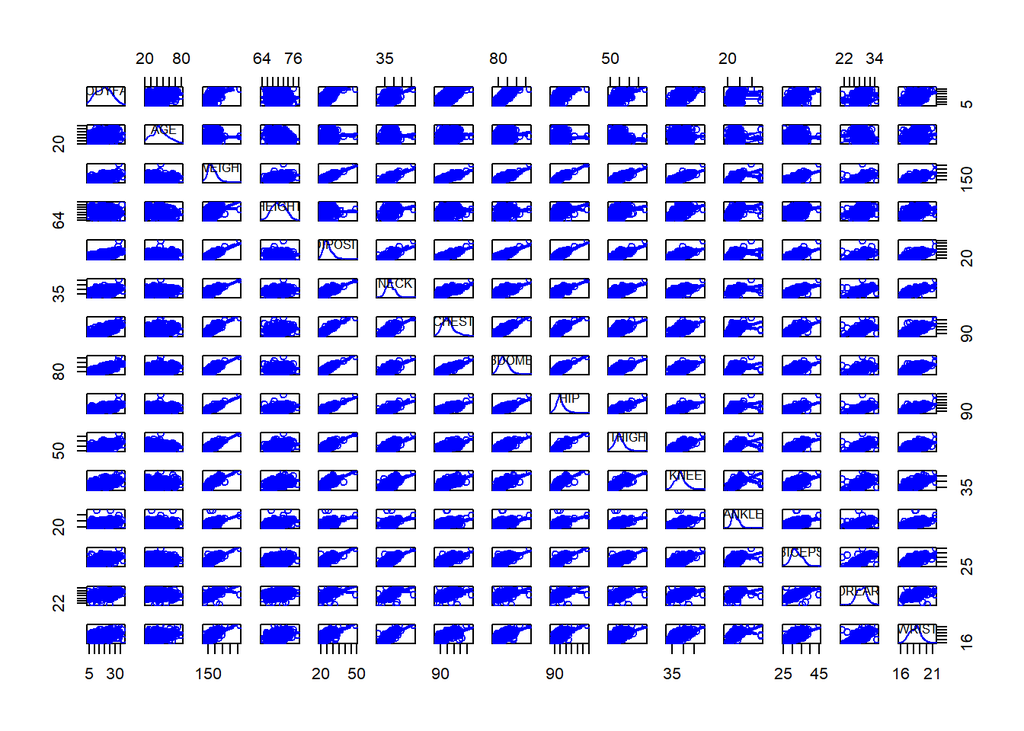

```r
# plot multi-scatterplot
scatterplotMatrix(BodyFat_clean)
```

```r
# correlation
cor(BodyFat_clean)
```

```
##               BODYFAT          AGE      WEIGHT      HEIGHT  ADIPOSITY      NECK
## BODYFAT    1.00000000  0.289706223  0.59805516 -0.01334157 0.70324588 0.4826477
## AGE        0.28970622  1.000000000 -0.02223131 -0.26444921 0.11152204 0.1088136
## WEIGHT     0.59805516 -0.022231308  1.00000000  0.49556017 0.89346944 0.8300627
## HEIGHT    -0.01334157 -0.264449214  0.49556017  1.00000000 0.05742733 0.3228476
## ADIPOSITY  0.70324588  0.111522044  0.89346944  0.05742733 1.00000000 0.7849730
## NECK       0.48264765  0.108813559  0.83006268  0.32284763 0.78497299 1.0000000
## CHEST      0.68949269  0.171793858  0.89115333  0.22900040 0.91225415 0.7815113
## ABDOMEN    0.80281740  0.229139979  0.88745142  0.20401747 0.91923880 0.7519608
## HIP        0.60393134 -0.061429812  0.94216612  0.39082569 0.88406561 0.7367977
## THIGH      0.54415066 -0.213663320  0.86876030  0.34594680 0.81930466 0.6958451
## KNEE       0.51132648  0.008638357  0.85752775  0.48822152 0.73381761 0.6811839
## ANKLE      0.25286782 -0.109199981  0.61164646  0.40239429 0.49793206 0.4696268
## BICEPS     0.47415234 -0.049567249  0.79621584  0.31946501 0.74847507 0.7253885
## FOREARM    0.35570391 -0.093966081  0.62189220  0.31347078 0.56054282 0.6099845
## WRIST      0.35830564  0.210687899  0.73691862  0.38620544 0.65091631 0.7401106
##               CHEST   ABDOMEN         HIP      THIGH        KNEE      ANKLE
## BODYFAT   0.6894927 0.8028174  0.60393134  0.5441507 0.511326478  0.2528678
## AGE       0.1717939 0.2291400 -0.06142981 -0.2136633 0.008638357 -0.1092000
## WEIGHT    0.8911533 0.8874514  0.94216612  0.8687603 0.857527751  0.6116465
## HEIGHT    0.2290004 0.2040175  0.39082569  0.3459468 0.488221516  0.4023943
## ADIPOSITY 0.9122541 0.9192388  0.88406561  0.8193047 0.733817612  0.4979321
## NECK      0.7815113 0.7519608  0.73679767  0.6958451 0.681183863  0.4696268
## CHEST     1.0000000 0.9125531  0.82474080  0.7259297 0.724057859  0.4738766
## ABDOMEN   0.9125531 1.0000000  0.87044764  0.7630662 0.748860647  0.4437200
## HIP       0.8247408 0.8704476  1.00000000  0.8936720 0.829497552  0.5554316
## THIGH     0.7259297 0.7630662  0.89367199  1.0000000 0.798906965  0.5318138
## KNEE      0.7240579 0.7488606  0.82949755  0.7989070 1.000000000  0.6111269
## ANKLE     0.4738766 0.4437200  0.55543159  0.5318138 0.611126883  1.0000000
## BICEPS    0.7250546 0.6767039  0.73621646  0.7560725 0.678618272  0.4757276
## FOREARM   0.5704467 0.4930647  0.53695126  0.5555135 0.548545961  0.4056079
## WRIST     0.6663840 0.6323546  0.64153228  0.5642517 0.673403310  0.5699051
##                BICEPS     FOREARM     WRIST
## BODYFAT    0.47415234  0.35570391 0.3583056
## AGE       -0.04956725 -0.09396608 0.2106879
## WEIGHT     0.79621584  0.62189220 0.7369186
## HEIGHT     0.31946501  0.31347078 0.3862054
## ADIPOSITY  0.74847507  0.56054282 0.6509163
## NECK       0.72538853  0.60998451 0.7401106
## CHEST      0.72505465  0.57044671 0.6663840
## ABDOMEN    0.67670389  0.49306474 0.6323546
## HIP        0.73621646  0.53695126 0.6415323
## THIGH      0.75607247  0.55551354 0.5642517
## KNEE       0.67861827  0.54854596 0.6734033
## ANKLE      0.47572761  0.40560786 0.5699051
## BICEPS     1.00000000  0.67181325 0.6368724
## FOREARM    0.67181325  1.00000000 0.5725394
## WRIST      0.63687238  0.57253940 1.0000000
```

```r
# partial correlation
cor2pcor(cor(BodyFat_clean))
```

```
##              [,1]        [,2]         [,3]        [,4]        [,5]        [,6]
##  [1,]  1.00000000  0.11063052 -0.136869594  0.09243525  0.09273982 -0.11055489
##  [2,]  0.11063052  1.00000000  0.025674753 -0.11112943 -0.09420057  0.10142850
##  [3,] -0.13686959  0.02567475  1.000000000  0.95127981  0.91803369  0.15492580
##  [4,]  0.09243525 -0.11112943  0.951279806  1.00000000 -0.97658313 -0.06167234
##  [5,]  0.09273982 -0.09420057  0.918033691 -0.97658313  1.00000000 -0.02713542
##  [6,] -0.11055489  0.10142850  0.154925798 -0.06167234 -0.02713542  1.00000000
##  [7,] -0.02782273  0.05036010 -0.077157552  0.20136557  0.28330234 -0.01438645
##  [8,]  0.56395870  0.29721369  0.056921238  0.03073086  0.08534278  0.03196429
##  [9,] -0.10890362 -0.03495139 -0.025448741  0.18527002  0.23455526 -0.19187273
## [10,]  0.11572713 -0.36975263  0.054561032 -0.04252400  0.01719812  0.07110996
## [11,]  0.01701127  0.21449627  0.094361436 -0.01710891 -0.06066118 -0.09094052
## [12,]  0.05508439 -0.08324065 -0.001251955  0.07486916  0.10181960 -0.12015947
## [13,]  0.06540472  0.05417303  0.128419976 -0.07664227 -0.05123527  0.06003997
## [14,]  0.13865360 -0.15351416 -0.139577876  0.16407763  0.16910343  0.12532042
```

[output cut: 33 more lines]

```r
# divide age into group varible
AGE.GROUP <- NULL

for (i in 1:length(BodyFat_clean$AGE)) {
  if (BodyFat_clean$AGE[i] < 30) {
    AGE.GROUP[i] <- 1
  }
  else if (BodyFat_clean$AGE[i] > 60){
    AGE.GROUP[i] <- 2
  }
  else{
    AGE.GROUP[i] <- 3
  }
}

AGE.GROUP <- as.factor(AGE.GROUP)

BodyFat_clean <- cbind(BodyFat_clean,AGE.GROUP)
```

## Rule of Thumb

1. With larger R2, the model is better
2. The number of parameters in the model is usually not greater than 5.

## Fit models

```r
# fit models
attach(BodyFat_clean)

#based on correlation
m1 <- lm(BODYFAT~ ABDOMEN)
summary(m1)
```

```
##
## Call:
## lm(formula = BODYFAT ~ ABDOMEN)
##
## Residuals:
##      Min       1Q   Median       3Q      Max
## -16.5511  -3.4182   0.0157   2.8313  11.9464
##
## Coefficients:
##              Estimate Std. Error t value            Pr(>|t|)
## (Intercept) -33.25576    2.51776  -13.21 <0.0000000000000002 ***
## ABDOMEN       0.56453    0.02701   20.90 <0.0000000000000002 ***
## ---
## Signif. codes:  0 '***' 0.001 '**' 0.01 '*' 0.05 '.' 0.1 ' ' 1
##
## Residual standard error: 4.437 on 241 degrees of freedom
## Multiple R-squared:  0.6445, Adjusted R-squared:  0.643
## F-statistic: 436.9 on 1 and 241 DF,  p-value: < 0.00000000000000022
```

```r
m2 <- lm(BODYFAT~ ABDOMEN + ADIPOSITY + CHEST)
summary(m2)
```

```
##
## Call:
## lm(formula = BODYFAT ~ ABDOMEN + ADIPOSITY + CHEST)
##
## Residuals:
##      Min       1Q   Median       3Q      Max
## -15.6439  -3.3732   0.2245   2.9177  12.0910
##
## Coefficients:
##              Estimate Std. Error t value             Pr(>|t|)
## (Intercept) -27.82925    4.40549  -6.317        0.00000000129 ***
## ABDOMEN       0.77695    0.07607  10.213 < 0.0000000000000002 ***
## ADIPOSITY    -0.26881    0.22548  -1.192                0.234
## CHEST        -0.18097    0.09347  -1.936                0.054 .
## ---
## Signif. codes:  0 '***' 0.001 '**' 0.01 '*' 0.05 '.' 0.1 ' ' 1
##
## Residual standard error: 4.373 on 239 degrees of freedom
## Multiple R-squared:  0.6577, Adjusted R-squared:  0.6534
## F-statistic: 153.1 on 3 and 239 DF,  p-value: < 0.00000000000000022
```

```r
#based on partial correlation
m3 <- lm(BODYFAT~ AGE  + ADIPOSITY + ABDOMEN+ CHEST + WRIST)
summary(m3)
```

```
##
## Call:
## lm(formula = BODYFAT ~ AGE + ADIPOSITY + ABDOMEN + CHEST + WRIST)
##
## Residuals:
##      Min       1Q   Median       3Q      Max
## -15.9297  -2.7083  -0.1725   2.9477   9.8652
##
## Coefficients:
##             Estimate Std. Error t value             Pr(>|t|)
## (Intercept) -4.96211    6.17027  -0.804               0.4221
## AGE          0.07404    0.02241   3.303               0.0011 **
## ADIPOSITY    0.03848    0.22146   0.174               0.8622
## ABDOMEN      0.71011    0.07465   9.512 < 0.0000000000000002 ***
## CHEST       -0.09390    0.08992  -1.044               0.2974
## WRIST       -2.00810    0.39341  -5.104          0.000000681 ***
## ---
## Signif. codes:  0 '***' 0.001 '**' 0.01 '*' 0.05 '.' 0.1 ' ' 1
##
## Residual standard error: 4.117 on 237 degrees of freedom
## Multiple R-squared:  0.699,  Adjusted R-squared:  0.6927
## F-statistic: 110.1 on 5 and 237 DF,  p-value: < 0.00000000000000022
```

```r
m4 <- lm(BODYFAT~ AGE  + log(ADIPOSITY) + log(ABDOMEN) + log(CHEST) + log(WRIST))
summary(m4)
```

```
##
## Call:
## lm(formula = BODYFAT ~ AGE + log(ADIPOSITY) + log(ABDOMEN) +
##     log(CHEST) + log(WRIST))
##
## Residuals:
##      Min       1Q   Median       3Q      Max
## -10.7963  -2.8076  -0.1848   2.9407   8.7124
##
## Coefficients:
##                  Estimate Std. Error t value             Pr(>|t|)
## (Intercept)    -114.69885   25.69685  -4.464         0.0000124705 ***
## AGE               0.07717    0.02164   3.567             0.000437 ***
## log(ADIPOSITY)   10.12435    5.76006   1.758             0.080093 .
## log(ABDOMEN)     62.91093    6.57205   9.573 < 0.0000000000000002 ***
## log(CHEST)      -15.72375    8.98822  -1.749             0.081521 .
## log(WRIST)      -39.43004    6.97290  -5.655         0.0000000447 ***
## ---
## Signif. codes:  0 '***' 0.001 '**' 0.01 '*' 0.05 '.' 0.1 ' ' 1
##
## Residual standard error: 3.982 on 237 degrees of freedom
## Multiple R-squared:  0.7185, Adjusted R-squared:  0.7126
## F-statistic:   121 on 5 and 237 DF,  p-value: < 0.00000000000000022
```

```r
m5 <- lm(BODYFAT~ AGE  + log(ABDOMEN) + log(WRIST))
summary(m5)
```

```
##
## Call:
## lm(formula = BODYFAT ~ AGE + log(ABDOMEN) + log(WRIST))
##
## Residuals:
##     Min      1Q  Median      3Q     Max
## -9.6734 -2.7614 -0.1802  2.8772  9.4384
##
## Coefficients:
##                Estimate Std. Error t value             Pr(>|t|)
## (Intercept)  -157.59313   15.08658 -10.446 < 0.0000000000000002 ***
## AGE             0.07087    0.02089   3.393             0.000809 ***
## log(ABDOMEN)   63.77138    3.00698  21.208 < 0.0000000000000002 ***
## log(WRIST)    -39.61400    6.57574  -6.024        0.00000000637 ***
## ---
## Signif. codes:  0 '***' 0.001 '**' 0.01 '*' 0.05 '.' 0.1 ' ' 1
##
## Residual standard error: 4.001 on 239 degrees of freedom
## Multiple R-squared:  0.7135, Adjusted R-squared:  0.7099
## F-statistic: 198.4 on 3 and 239 DF,  p-value: < 0.00000000000000022
```

```r
m6 <- lm(BODYFAT ~ AGE.GROUP +  log(ABDOMEN) + log(WRIST),data = BodyFat_clean)
summary(m6)
```

```
##
## Call:
## lm(formula = BODYFAT ~ AGE.GROUP + log(ABDOMEN) + log(WRIST),
##     data = BodyFat_clean)
##
## Residuals:
##    Min     1Q Median     3Q    Max
## -9.665 -2.599 -0.286  2.856  9.566
##
## Coefficients:
##               Estimate Std. Error t value             Pr(>|t|)
## (Intercept)  -155.7116    15.2290 -10.225 < 0.0000000000000002 ***
## AGE.GROUP2      3.7541     0.9867   3.805              0.00018 ***
## AGE.GROUP3      1.4426     0.7480   1.929              0.05497 .
## log(ABDOMEN)   62.9290     3.0527  20.614 < 0.0000000000000002 ***
## log(WRIST)    -38.3889     6.6573  -5.766          0.000000025 ***
## ---
## Signif. codes:  0 '***' 0.001 '**' 0.01 '*' 0.05 '.' 0.1 ' ' 1
##
## Residual standard error: 3.982 on 238 degrees of freedom
## Multiple R-squared:  0.7174, Adjusted R-squared:  0.7126
## F-statistic:   151 on 4 and 238 DF,  p-value: < 0.00000000000000022
```

```r
detach(BodyFat_clean)
```

## Visualizing

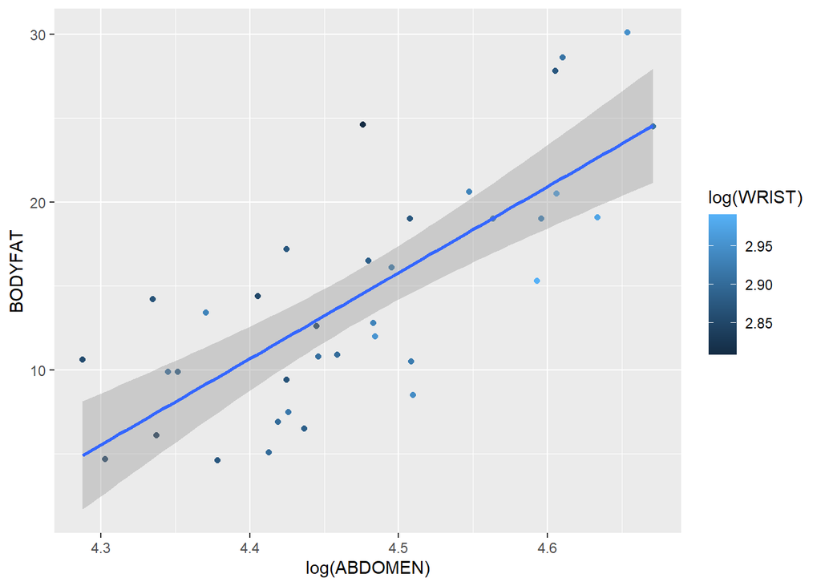

```r
# Visualizing multiple linear regression models

ggplot(subset(subset(BodyFat_clean,AGE.GROUP  == 1)),aes(y=BODYFAT,x=log(ABDOMEN),color=log(WRIST)))+geom_point()+stat_smooth(method="lm",se=TRUE)
```

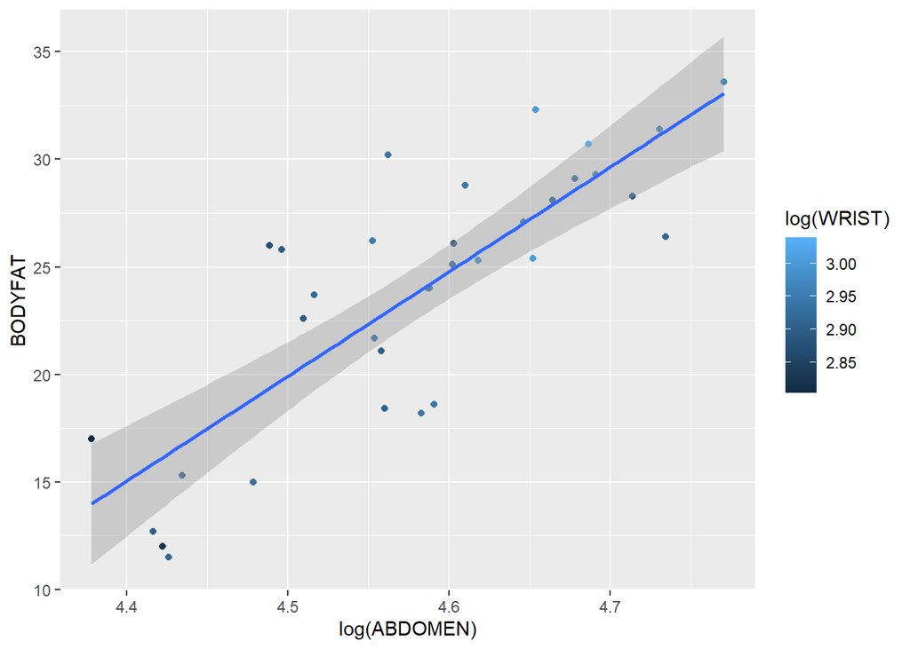

```r
ggplot(subset(subset(BodyFat_clean,AGE.GROUP  == 2)),aes(y=BODYFAT,x=log(ABDOMEN),color=log(WRIST)))+geom_point()+stat_smooth(method="lm",se=TRUE)
```

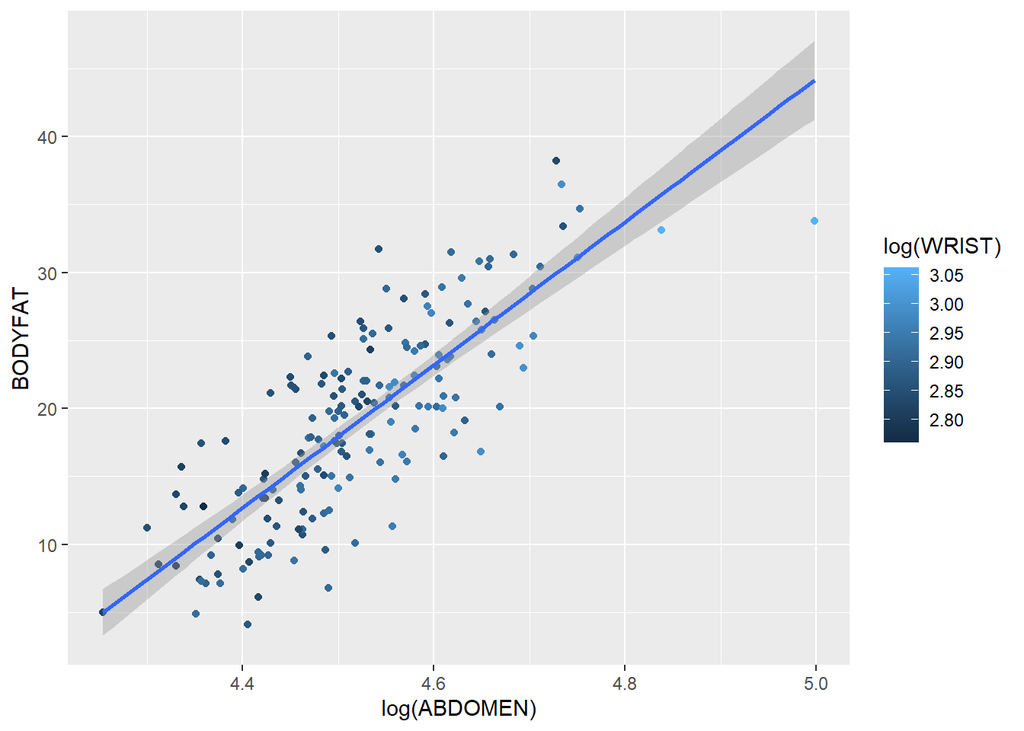

```r
ggplot(subset(subset(BodyFat_clean,AGE.GROUP  == 3)),aes(y=BODYFAT,x=log(ABDOMEN),color=log(WRIST)))+geom_point()+stat_smooth(method="lm",se=TRUE)
```

## Robust

```r
## test the robust of model

# Divide the data
n <- nrow(BodyFat_clean)
mark <- rep(FALSE, n)
mark[sample(n, round(2*n/3))] <- TRUE
training.set <- BodyFat_clean[mark, ]
test.set <- BodyFat_clean[!mark, ]

m <- lm(BODYFAT ~ AGE.GROUP +  log(ABDOMEN) + log(WRIST),data = training.set)
summary(m)
```

```
##
## Call:
## lm(formula = BODYFAT ~ AGE.GROUP + log(ABDOMEN) + log(WRIST),
##     data = training.set)
##
## Residuals:
##     Min      1Q  Median      3Q     Max
## -8.5708 -2.5043 -0.2948  2.6306  9.3946
##
## Coefficients:
##               Estimate Std. Error t value             Pr(>|t|)
## (Intercept)  -163.1254    17.6726  -9.230 < 0.0000000000000002 ***
## AGE.GROUP2      3.3983     1.1204   3.033              0.00283 **
## AGE.GROUP3      0.9445     0.8512   1.110              0.26885
## log(ABDOMEN)   64.1853     3.3148  19.363 < 0.0000000000000002 ***
## log(WRIST)    -37.5549     7.2347  -5.191          0.000000639 ***
## ---
## Signif. codes:  0 '***' 0.001 '**' 0.01 '*' 0.05 '.' 0.1 ' ' 1
##
## Residual standard error: 3.639 on 157 degrees of freedom
## Multiple R-squared:  0.7571, Adjusted R-squared:  0.7509
## F-statistic: 122.4 on 4 and 157 DF,  p-value: < 0.00000000000000022
```

```r
# test the model
test <- predict(m,test.set)

R2 <- 1 - sum((test.set$BODYFAT - test)^2)/sum((test.set$BODYFAT - mean(test.set$BODYFAT))^2)
R2.adj <- 1 -  (1 - R2 ) * (nrow(test.set)-1)/(nrow(test.set) - length(test.set) - 1)

R2
```

```
## [1] 0.6198062
```

```r
R2.adj
```

```
## [1] 0.5247578
```

## Diagnosis the data

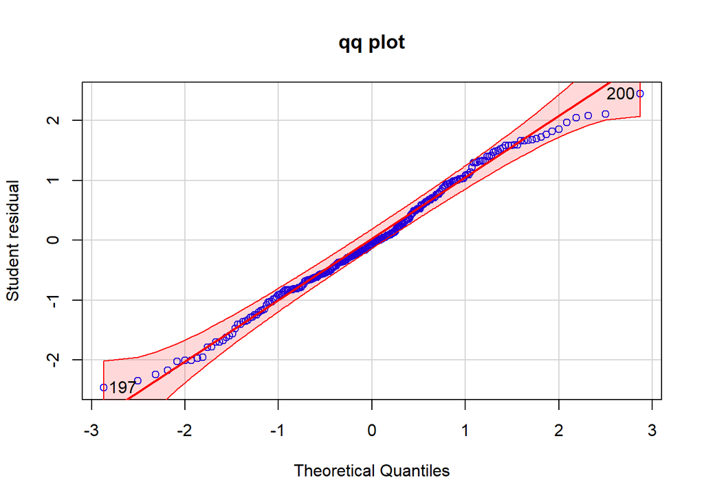

```
## [1] 197 200
```

```r
stu.residual <- rstudent(m6)

# normality
qqPlot(stu.residual , main="qq plot", col="blue", col.lines="red",xlab = "Theoretical Quantiles",ylab = "Student residual")
```

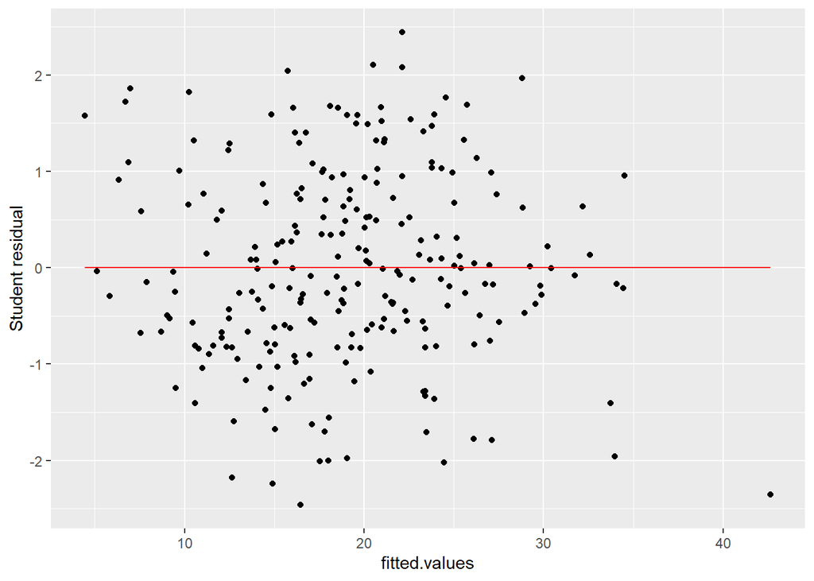

```r
# equal variance and linearity
ggplot( mapping = aes(x = m6$fitted.values, y = stu.residual)) + geom_point() + geom_line(y = 0,col = "red") + labs(x = "fitted.values",y= "Student residual")
```

```r
# outiler
cook <- cooks.distance(m6)
head(sort(cook,decreasing = TRUE)) # Rule of Thumb is to compare cook distance with 1
```

```
##         39        229          3         78         33         73
## 0.10788663 0.03704597 0.03033960 0.02694236 0.02615872 0.02528428
```

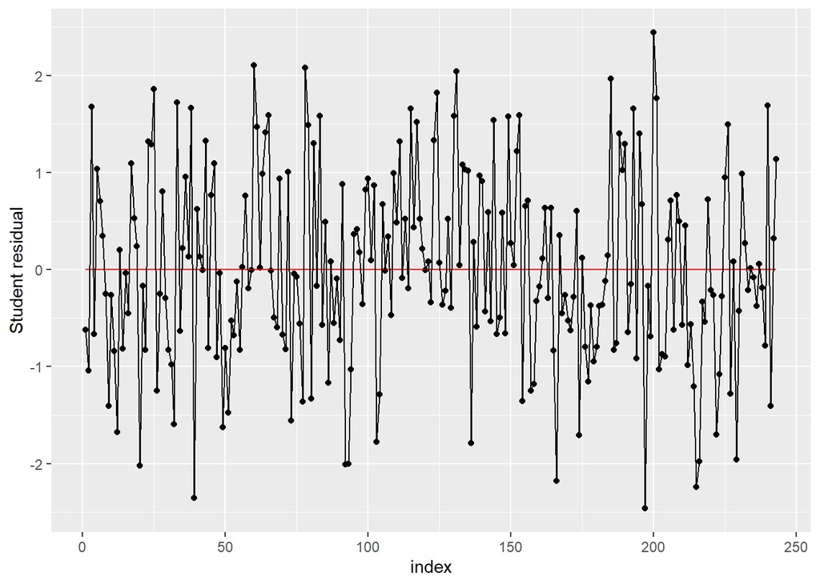

```r
# independece
ggplot( mapping = aes(y = stu.residual,x = c(1:length(stu.residual)))) + geom_point()+ geom_line(y = 0,col = "red") + labs(x = "index",y= "Student residual") + geom_line()
```

```r
# Multicollinearity
vif_i <- vif(m6)

maxvif <- max(vif_i[,3])
maxvif
```

```
## [1] 1.323161
```

```r
vif <- mean(vif_i[,3])
vif
```

```
## [1] 1.221047
```

## Remedy the model

The max of the largest VIF value among $VIF_i$ is not larger than 10, and the mean vif is not considerablygreater than 1, but nearly equal to 1, so there is not multicollinearity.

```r
new <- BodyFat_clean[-39,]

m <- lm(BODYFAT ~ AGE.GROUP +  log(ABDOMEN) + log(WRIST),data = new)

summary(m)
```

```
##
## Call:
## lm(formula = BODYFAT ~ AGE.GROUP + log(ABDOMEN) + log(WRIST),
##     data = new)
##
## Residuals:
##     Min      1Q  Median      3Q     Max
## -9.6901 -2.6068 -0.2707  2.7776  9.5185
##
## Coefficients:
##               Estimate Std. Error t value             Pr(>|t|)
## (Intercept)  -164.5631    15.5490 -10.584 < 0.0000000000000002 ***
## AGE.GROUP2      3.5748     0.9804   3.646             0.000327 ***
## AGE.GROUP3      1.4339     0.7410   1.935             0.054177 .
## log(ABDOMEN)   64.3598     3.0847  20.864 < 0.0000000000000002 ***
## log(WRIST)    -37.5437     6.6047  -5.684         0.0000000384 ***
## ---
## Signif. codes:  0 '***' 0.001 '**' 0.01 '*' 0.05 '.' 0.1 ' ' 1
##
## Residual standard error: 3.944 on 237 degrees of freedom
## Multiple R-squared:  0.7192, Adjusted R-squared:  0.7145
## F-statistic: 151.8 on 4 and 237 DF,  p-value: < 0.00000000000000022
```

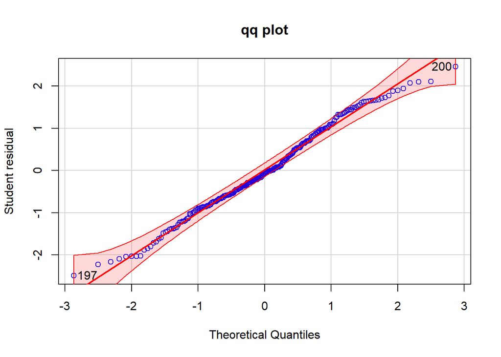

```
## 197 200
## 196 199
```

```r
stu.residual <- rstudent(m)

# normality
qqPlot(stu.residual , main="qq plot", col="blue", col.lines="red",xlab = "Theoretical Quantiles",ylab = "Student residual")
```

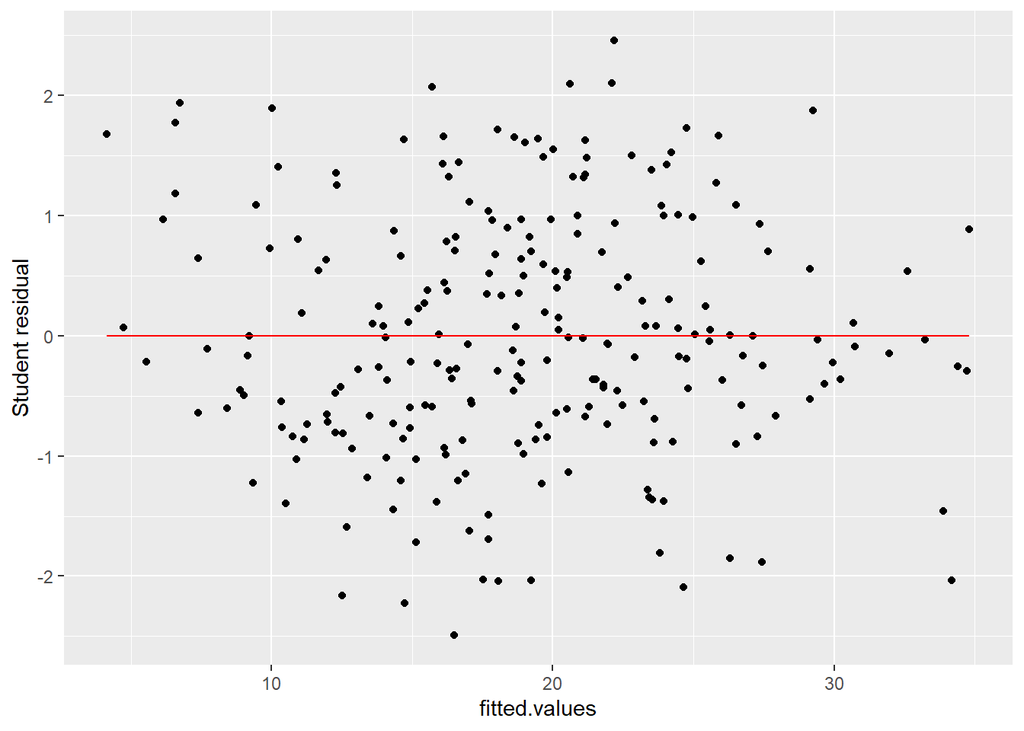

```r
# equal variance and linearity
ggplot( mapping = aes(x = m$fitted.values, y = stu.residual)) + geom_point() + geom_line(y = 0,col = "red") + labs(x = "fitted.values",y= "Student residual")
```

```r
# outiler
cook <- cooks.distance(m)
head(sort(cook,decreasing = TRUE)) # Rule of Thumb is to compare cook distance with 1
```

```
##        229          3         33         78         25        149
## 0.04034144 0.03165691 0.02772414 0.02755819 0.02719810 0.02412026
```

Compare the initial model, the coefficient just change a little, and the plots also does not change much. We can conclude that those points are not influential. Thus, we do not need to change the model.